# 통계밥법론 Chap13 실습코드

202140191 엄태훈

2021-05-15(SAT)

# Chap13 Design of Experiments - Factorial Desings

**삼원분산분석(Three-way ANOVA)**는 앞서 우리가 살펴본 이원분산분석(Two-Way ANOVA)과 달리 **독립변수가 3개** 이상인 분산분석을 일컫는다.  
앞서 우리가 진행했던 이원분산분석에서는 두 독립변수간의 교호작용만을 고려했다.

하지만, 삼원분산분석의 경우, 독립변수가 3개 이상이기 때문에 두 독립변수간 교호작용이 3개 이상이 나올 수 있다.  
또한, 독립변수 3개에 대한 교호작용도 살펴봐야한다.

주효과와 교호작용에 대한 귀무가설과 대립가설은 앞서 살펴본 분산분석들과 동일하다.

**주효과의 대립가설**

- H0: 독립변수 A에 따른 종속변수 B에 대하여 평균차이가 없다.
- H1: 독립변수 A에 따른 종속변수 B에 대하여 평균차이가 있다.

**교호작용의 대립가설**

- H0: 독립변수간 교호작용 효과가 존재하지 않는다.
- H1: 독립변수간 교호작용 효과가 존재한다.

## 13.1 A Three-Way ANOVA - Muscle Data

`cc176`은 근육 데이터로 구성된 데이터로, `HH`패키지 안에 내장돼있다.

```r
library(HH)
data("cc176")
```

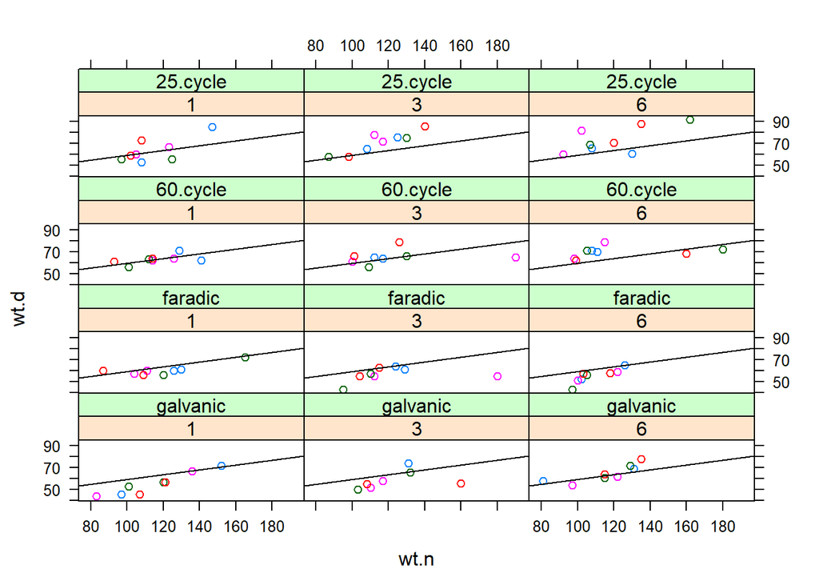

```r
xyplot(wt.d~wt.n|n.treats*current,data=cc176,group=minutes,
        panel=function(x,y,...) {
         panel.superpose(x,y,...)
         panel.abline(lm(cc176$wt.d ~ cc176$wt.n))})
```

`cc176`의 **group(n.treats,current)**에 대한 EDA를 진행하기 위해 `xyplot`함수를 사용하여 그림을 그렸다.  
또한, 공변량에 대해 회귀직선을 표시했으며, 회귀직선이 양의 기울기를 가지는 것으로 보아 변수간 효과가 있는 것을 알 수 있다.

```r
## y=wt.d with x=wt.n as covariate
## (get essentially the same ANOVA as the approximate (y-bx)^2)
## ANOVA table in Cochran and Cox)
cc176.aov <- aov(wt.d~rep+wt.n+n.treats*minutes*current,data=cc176)
summary(cc176.aov)
```

```
##                          Df Sum Sq Mean Sq F value   Pr(>F)
## rep                       1  605.0   605.0  12.582 0.000909 ***
## wt.n                      1 1334.1  1334.1  27.744 3.57e-06 ***
## n.treats                  2  438.9   219.4   4.563 0.015566 *
## minutes                   3  183.9    61.3   1.275 0.294092
## current                   3 2114.4   704.8  14.657 7.82e-07 ***
## n.treats:minutes          6  198.4    33.1   0.688 0.660507
## n.treats:current          6  491.5    81.9   1.704 0.141632
## minutes:current           9  382.6    42.5   0.884 0.546266
## n.treats:minutes:current 18 1021.6    56.8   1.180 0.315421
## Residuals                46 2212.0    48.1
## ---
## Signif. codes:  0 '***' 0.001 '**' 0.01 '*' 0.05 '.' 0.1 ' ' 1
```

3개의 변수(**n.treats**,**minutes**,**current**)를 교호작용으로 지정하여 분산분석을 진행하였다.

분산분석 결과, minutes를 제외한 모든 주효과는 유의확률이 유의수준보다 작으므로, ’유의한 차이가 존재하는 집단이 적어도 한 집단 이상이다.’는 결과를 얻을 수 있었다.

교호작용의 결과를 살펴본 결과, 유의한 교호작용은 존재하지 않았다.

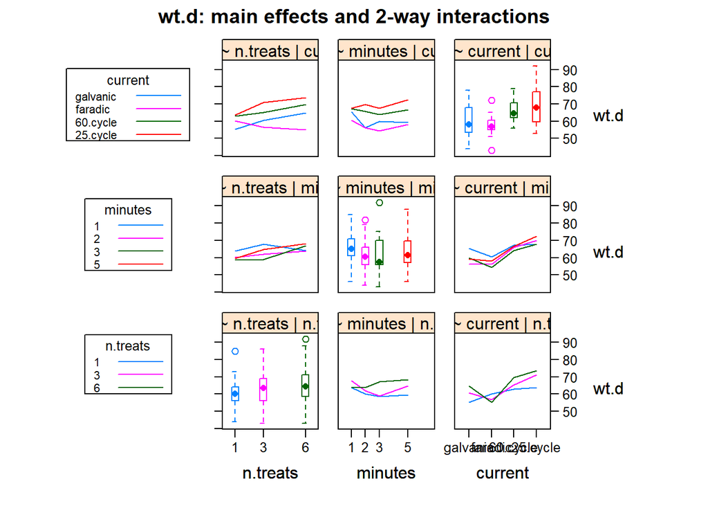

```r
interaction2wt(wt.d~n.treats*minutes*current,data=cc176)
```

`interaction2wt` 함수를 통해 3개의 교호작용에 대한 plotㅇ르 살펴볼 수 있다.

```r
summary(cc176.aov,
        split=list(n.treats=list(n.treats.lin=1,
                                 n.treats.quad=2)),
        expand.split=FALSE)
```

```
##                           Df Sum Sq Mean Sq F value   Pr(>F)
## rep                        1  605.0   605.0  12.582 0.000909 ***
## wt.n                       1 1334.1  1334.1  27.744 3.57e-06 ***
## n.treats                   2  438.9   219.4   4.563 0.015566 *
##   n.treats: n.treats.lin   1  438.2   438.2   9.114 0.004129 **
##   n.treats: n.treats.quad  1    0.6     0.6   0.013 0.910476
## minutes                    3  183.9    61.3   1.275 0.294092
## current                    3 2114.4   704.8  14.657 7.82e-07 ***
## n.treats:minutes           6  198.4    33.1   0.688 0.660507
## n.treats:current           6  491.5    81.9   1.704 0.141632
## minutes:current            9  382.6    42.5   0.884 0.546266
## n.treats:minutes:current  18 1021.6    56.8   1.180 0.315421
## Residuals                 46 2212.0    48.1
## ---
## Signif. codes:  0 '***' 0.001 '**' 0.01 '*' 0.05 '.' 0.1 ' ' 1
```

**n.treats** 변수에 대하여 2차 방정식을 적용하여 결과를 살펴보았다.

**n.treats**를 2차로 변환하게 되면 유의하지 않게 변하는 것을 알 수 있다.

```r
##
## adjust y for x
cc176$y.adj <- cc176$wt.d -
  (cc176$wt.n - mean(cc176$wt.n))*coef(cc176.aov)["wt.n"]
```

cc176의 y변수인 `wt.d`에 대하여 분산분석을 통해 얻어진 평균과 회귀계수를 통해 값을 조정해주었다.

```r
## duplicate CC Table 5.17
cc176.means <- tapply(cc176$y.adj,
                      cc176[,c("current","n.treats")],mean)

cc176.means
```

```
##           n.treats
## current           1        3        6
##   galvanic 56.03380 59.08068 65.28547
##   faradic  59.94734 55.79464 57.27463
##   60.cycle 63.25526 63.92297 68.57735
##   25.cycle 64.47088 71.78380 73.19818
```

```r
apply(cc176.means,1,function(x) mean(x))
```

```
## galvanic  faradic 60.cycle 25.cycle
## 60.13332 57.67220 65.25186 69.81762
```

`tapply`를 통해 **current**, **n.treats**에 따른 조정된 y의 평균 값을 살펴볼 수 있다.

`apply`를 사용하여 옵션을 1로 지정하면 (행에 대한 함수 적용) **current**에 따른 평균만을 얻을수도 있다.

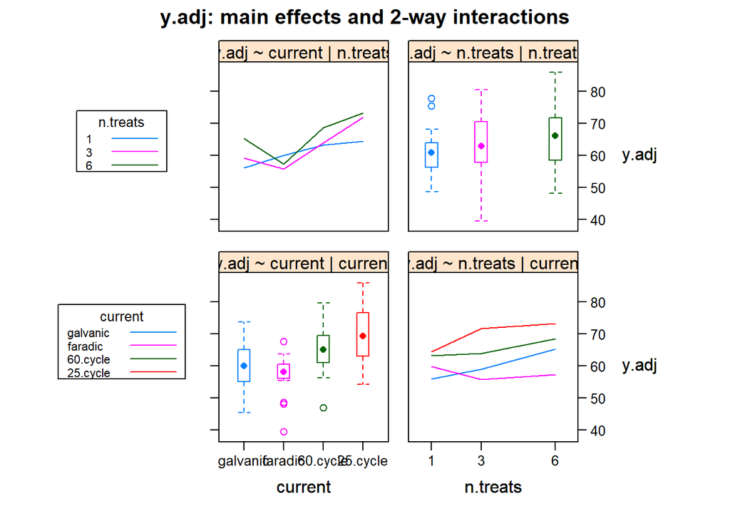

```r
interaction2wt(y.adj~current*n.treats,data=cc176)
```

조정된 y값에 대해서 **ntreats, current**의 교호작용 그림을 그려주었다.

교호작용 패널들에서 교차점이 몇 개 보이지만, 대부분 평행을 이루기 때문에 교호작용은 유의하지 않은 것을 알 수 있다.

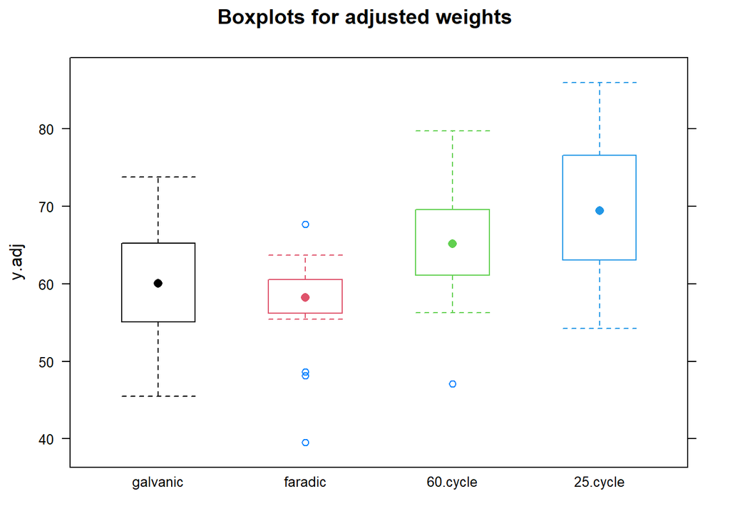

```r
bwplot(y.adj~current,data=cc176,main="Boxplots for adjusted weights",col=c(1:4),
       par.settings=list(box.rectangle=list(col=c(1:4)),
                         box.umbrella=list(col=c(1:4))))
```

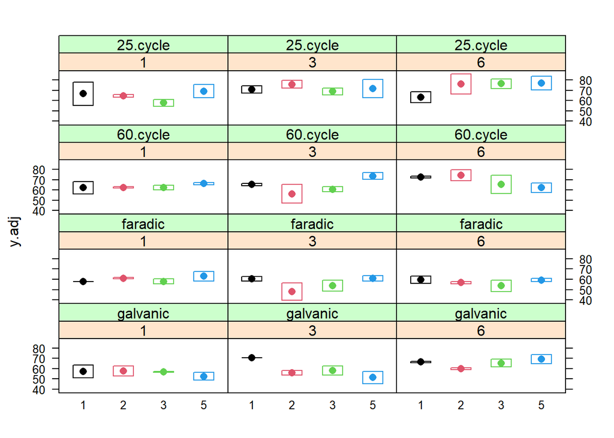

```r
bwplot(y.adj~minutes|n.treats*current,data=cc176,col=c(1:4),
       par.settings=list(box.rectangle=list(col=c(1:4)),
                         box.umbrella=list(col=c(1:4))))
```

조정된 값 y에 대한 minutes의 boxplot을 그려주었다.  
**ntreats,current**을 그룹변수로 하여 두 개의 그룹변수에 따라 **boxplot**을 나누어 그려주었다.

```r
cc176t <- cc176
for (i in names(cc176t))
  if (is.factor(cc176t[[i]]))
    contrasts(cc176t[[i]]) <-
  contr.treatment(length(levels(cc176t[[i]])))
sapply(cc176t,class)
```

```
## $wt.d
## [1] "numeric"
##
## $wt.n
## [1] "numeric"
##
## $n.treats
## [1] "positioned" "ordered"    "factor"
##
## $current
## [1] "positioned" "ordered"    "factor"
##
## $minutes
## [1] "positioned" "ordered"    "factor"
##
## $rep
## [1] "factor"
##
## $y.adj
## [1] "numeric"
```

```r
cc176t.aov <- aov(wt.d ~ rep + wt.n + n.treats +
                    wt.n*current,data=cc176t)
summary(cc176t.aov)
```

```
##              Df Sum Sq Mean Sq F value   Pr(>F)
## rep           1    605   605.0  14.192 0.000304 ***
## wt.n          1   1334  1334.1  31.293 2.65e-07 ***
## n.treats      2    439   219.4   5.147 0.007763 **
## current       3   2114   704.7  16.531 1.51e-08 ***
## wt.n:current  3    867   288.8   6.775 0.000376 ***
## Residuals    85   3624    42.6
## ---
## Signif. codes:  0 '***' 0.001 '**' 0.01 '*' 0.05 '.' 0.1 ' ' 1
```

앞서 진행한 분산분석과 다르게 주효과왁 교호작용을 지정해주었다.  
주효과는 모두 유의확률이 유의수준보다 작으므로 유의한 집단이 적어도 하나 존재하는 것을 알 수 있다.  
교호작용인 **wt.n:current** 또한 유의확률이 0.000376으로 두 변수의 교호작용은 유의한 것을 알 수 있다.

**current** 변수에 대한 다중비교를 진행하고 원하는 집단 간 차이를 살펴보기 위해 **contrast matrix**를 만들어 주었다.

```r
cc176$current <- factor(cc176$current,levels=unique(cc176$current),ordered=FALSE)
unique(cc176$current)
```

```
## [1] galvanic faradic  60.cycle 25.cycle
## Levels: galvanic faradic 60.cycle 25.cycle
```

```r
current.lmat <-cbind("gf-cc"=c(-1,-1,1,1),
                      "25-60"=c(0,0,-1,1),
                      "g-f"=c(1,-1,0,0))
dimnames(current.lmat)[[1]] <- levels(cc176$current)
cc176_current.aov <- aov(y.adj~current,data=cc176)
mmc(cc176_current.aov,focus="current",focus.lmat = current.lmat)
```

```
## Tukey contrasts
## Fit: aov(formula = y.adj ~ current, data = cc176)
## Estimated Quantile = 2.617173
## 95% family-wise confidence level
## $mca
##                    estimate   stderr      lower     upper   height
## 25.cycle-60.cycle  4.565762 2.123892 -0.9928299 10.124354 67.53474
## 25.cycle-galvanic  9.684305 2.123892  4.1257128 15.242897 64.97547
## 25.cycle-faradic  12.145417 2.123892  6.5868246 17.704009 63.74491
## 60.cycle-galvanic  5.118543 2.123892 -0.4400493 10.677135 62.69259
## 60.cycle-faradic   7.579654 2.123892  2.0210625 13.138246 61.46203
## galvanic-faradic   2.461112 2.123892 -3.0974802  8.019704 58.90276
## $none
##          estimate   stderr    lower    upper   height
## 25.cycle 69.81762 1.501818 65.88710 73.74814 69.81762
## 60.cycle 65.25186 1.501818 61.32134 69.18238 65.25186
## galvanic 60.13332 1.501818 56.20280 64.06383 60.13332
## faradic  57.67220 1.501818 53.74169 61.60272 57.67220
## $lmat
##       estimate   stderr      lower     upper   height
## 25-60 4.565762 2.123892 -0.9928299 10.124354 67.53474
## gf-cc 8.631980 1.501818  4.7014615 12.562498 63.21875
## g-f   2.461112 2.123892 -3.0974802  8.019704 58.90276
```

**current**변수에 따른 다중비교 결과와 우리가 설정한 집단 간 평균차이 결과를 볼 수 있다.

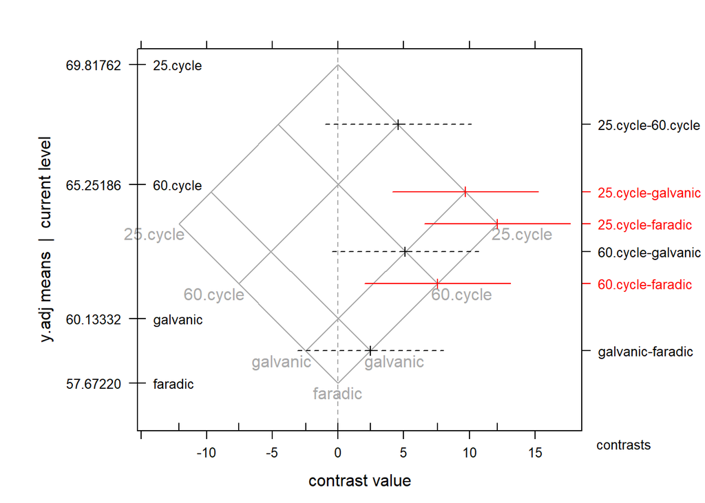

```r
mmcplot(mmc(cc176_current.aov,focus="current",focus.lmat = current.lmat))
```

`mmcplolt`을 통해서 살펴본 결과 평균차이가 유의하게 나타나는 집단은 다음과 같다.  
**25.cycle-galavnic**, **25.cycle-faradic**, **60.cycle-faradic**

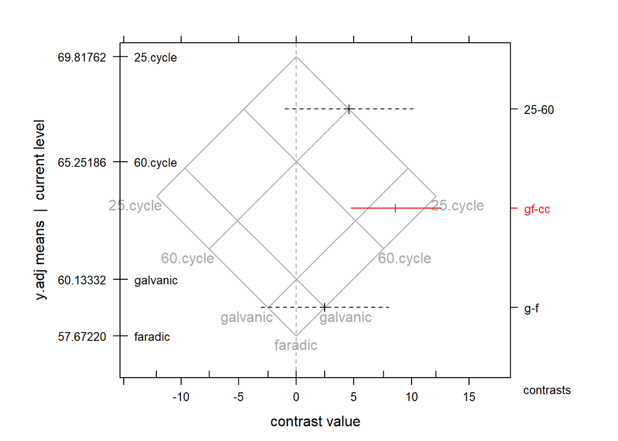

```r
mmcplot(mmc(cc176_current.aov,focus="current",focus.lmat = current.lmat),type="lmat")
```

`type=lmat`옵션을 이용하여 우리가 설정한 집단 간 차이를 살펴본 결과, 유의한 차이가 나타나는 집단은 **gf-cc** 하나뿐 이었다.

### 13.2.1 Example - Latin Square

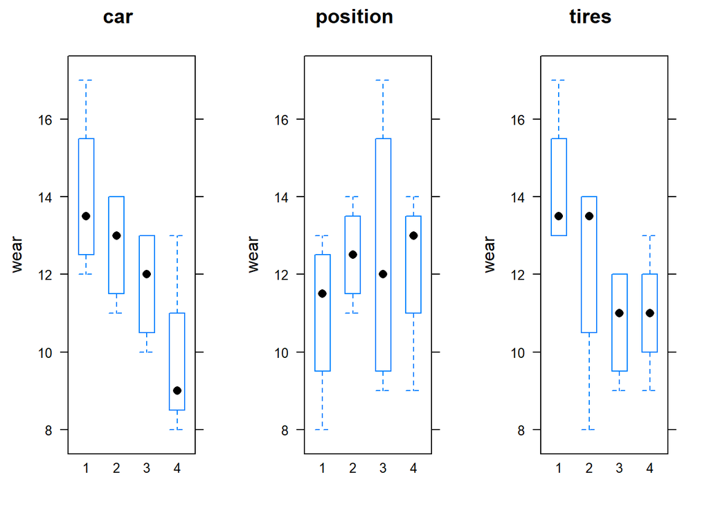

```r
data(tires)
library(gridExtra)
b1<-bwplot(wear~car,data=tires,main="car")
b2<-bwplot(wear~position,data=tires,main="position")
b3<-bwplot(wear~brand,data=tires,main="tires")


print(b1,split=c(1,1,3,1),more=TRUE)
print(b2,split=c(2,1,3,1),more=TRUE)
print(b3,split=c(3,1,3,1),more=FALSE)
```

**tires**데이터에 대한 시각적 탐색을 위해 `boxplot`을 그렸다.  
**car** 변수의 경우, 숫자가 커질수록 wear의 값이 낮아지는 것을 알 수 있다.

```r
tires.aov <- aov(wear~ car+position+brand,data=tires)
summary(tires.aov)
```

```
##             Df Sum Sq Mean Sq F value  Pr(>F)
## car          3  38.69  12.896  14.395 0.00378 **
## position     3   6.19   2.062   2.302 0.17695
## brand        3  30.69  10.229  11.419 0.00683 **
## Residuals    6   5.38   0.896
## ---
## Signif. codes:  0 '***' 0.001 '**' 0.01 '*' 0.05 '.' 0.1 ' ' 1
```

`tires`데이터에 대한 분산분석 진행결과, **position** 변수를 제외한 두 **car,brand** 주효과 변수가 유의한 것을 알 수 있다.  
따라서, 두 주효과 집단에서는 유의한 차이가 발생하는 집단이 적어도 하나 존재한다.

```r
tapply(tires$wear,tires$car,function(x) mean(x))
```

```
##     1     2     3     4
## 14.00 12.75 11.75  9.75
```

```r
tapply(tires$wear,tires$position,function(x) mean(x))
```

```
##     1     2     3     4
## 11.00 12.50 12.50 12.25
```

```r
tapply(tires$wear,tires$brand,function(x) mean(x))
```

```
##     1     2     3     4
## 14.25 12.25 10.75 11.00
```

`tapply`함수를 적용하여 **tires**의 각 변수에 대한 평균을 구해주었다.

```r
tires.mmc.brand <- mmc(tires.aov,linfct=mcp(brand="Tukey"))

tires.mmc.brand
```

```
## Tukey contrasts
## Fit: aov(formula = wear ~ car + position + brand, data = tires)
## Estimated Quantile = 3.460797
## 95% family-wise confidence level
## $mca
##     estimate    stderr     lower    upper height
## 1-2     2.00 0.6692658 -0.316193 4.316193 13.250
## 1-4     3.25 0.6692658  0.933807 5.566193 12.625
## 1-3     3.50 0.6692658  1.183807 5.816193 12.500
## 2-4     1.25 0.6692658 -1.066193 3.566193 11.625
## 2-3     1.50 0.6692658 -0.816193 3.816193 11.500
## 4-3     0.25 0.6692658 -2.066193 2.566193 10.875
## $none
##   estimate    stderr     lower   upper height
## 1    14.25 0.4732424 12.612204 15.8878  14.25
## 2    12.25 0.4732424 10.612204 13.8878  12.25
## 4    11.00 0.4732424  9.362204 12.6378  11.00
## 3    10.75 0.4732424  9.112204 12.3878  10.75
```

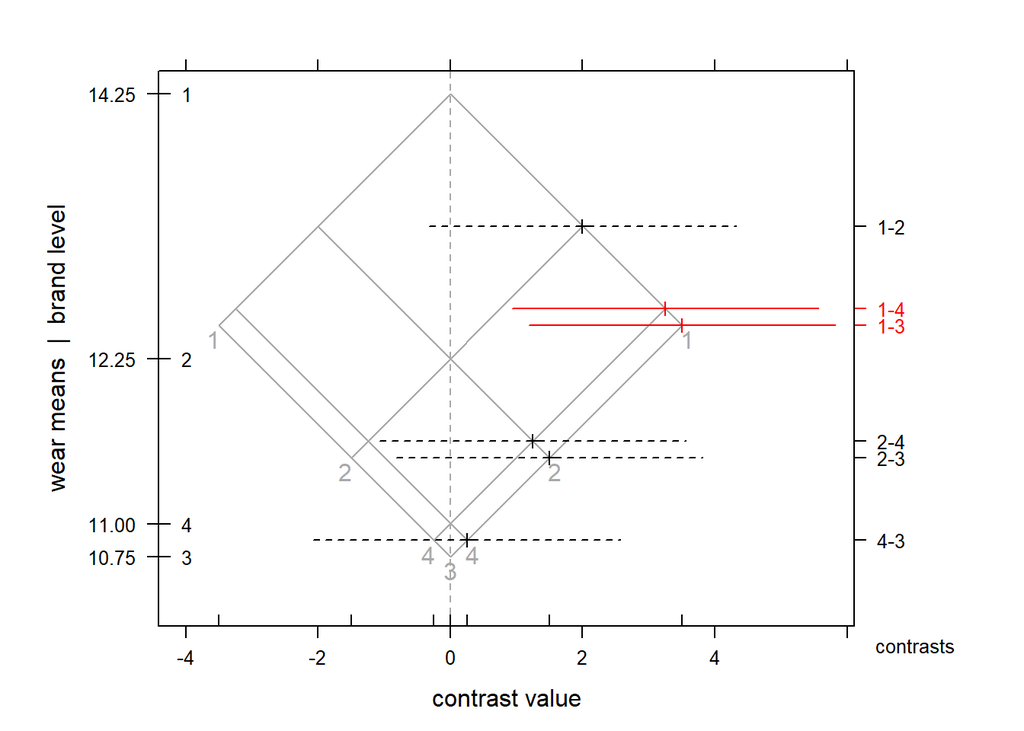

```r
mmcplot(tires.mmc.brand)
```

**brand**변수에 대한 다중비교를 진행하였다.  
1-4, 1-3집단이 신뢰구간 0을 포함하지 않고 다중비교 plot에서 붉은색으로 지정된 것으로 보아 유의한 차이가 있는 집단인 것을 확인할 수 있다.

```r
brand.lmat <- cbind("1-43" =c(2,0,-1,-1),
                    "4-3" =c(0,0,-1,1),
                    "143-2" = c(1,-3,1,1))

dimnames(brand.lmat)[[1]] <- levels(tires$brand)


tires.mmc.brand2 <- mmc(tires.aov,linfct=mcp(brand="Tukey"),
                       focus.lmat = brand.lmat)

tires.mmc.brand2
```

```
## Tukey contrasts
## Fit: aov(formula = wear ~ car + position + brand, data = tires)
## Estimated Quantile = 3.461053
## 95% family-wise confidence level
## $mca
##     estimate    stderr      lower    upper height
## 1-2     2.00 0.6692658 -0.3163642 4.316364 13.250
## 1-4     3.25 0.6692658  0.9336358 5.566364 12.625
## 1-3     3.50 0.6692658  1.1836358 5.816364 12.500
## 2-4     1.25 0.6692658 -1.0663642 3.566364 11.625
## 2-3     1.50 0.6692658 -0.8163642 3.816364 11.500
## 4-3     0.25 0.6692658 -2.0663642 2.566364 10.875
## $none
##   estimate    stderr     lower    upper height
## 1    14.25 0.4732424 12.612083 15.88792  14.25
## 2    12.25 0.4732424 10.612083 13.88792  12.25
## 4    11.00 0.4732424  9.362083 12.63792  11.00
## 3    10.75 0.4732424  9.112083 12.38792  10.75
## $lmat
##       estimate    stderr     lower    upper  height
## 1-43     3.375 0.5796012  1.368970 5.381030 12.5625
## 2-143    0.250 0.5464532 -1.641303 2.141303 12.1250
## 4-3      0.250 0.6692658 -2.066364 2.566364 10.8750
```

원하는 집단 간 차이를 살펴보기 위해 contrast matrix를 만들어 주었다.  
**1-43** 집단만이 신뢰구간 0을 포함하지 않으므로 유의한 차이가 있는 집단인 것을 알 수 있다.

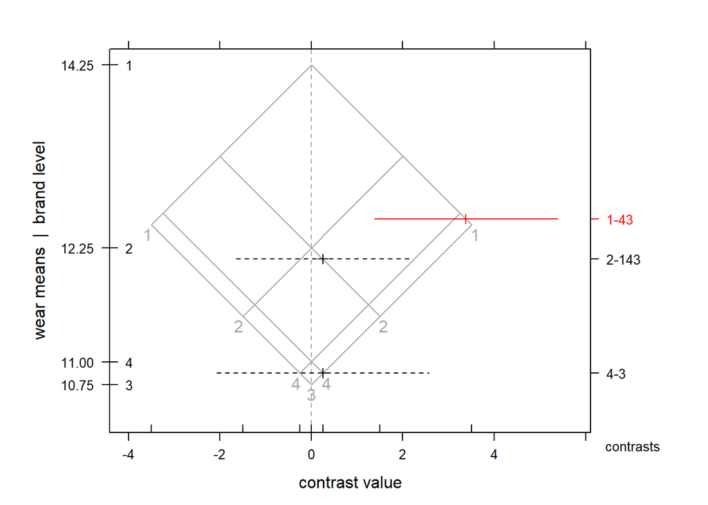

```r
mmcplot(tires.mmc.brand2,type="lmat")
```

`mmcplot`에서도 유의한 집단 간 차익가 있는 **1-43** 집단이 붉은색으로 지정된 것을 볼 수 있다.

```r
tires.aov <- aov(wear ~ car + position + brand, data=tires)

summary(tires.aov,split=list(brand=list("1-43"=1,rest=2:3)))
```

```
##               Df Sum Sq Mean Sq F value  Pr(>F)
## car            3  38.69  12.896  14.395 0.00378 **
## position       3   6.19   2.062   2.302 0.17695
## brand          3  30.69  10.229  11.419 0.00683 **
##   brand: 1-43  1   0.19   0.187   0.209 0.66341
##   brand: rest  2  30.50  15.250  17.023 0.00336 **
## Residuals      6   5.38   0.896
## ---
## Signif. codes:  0 '***' 0.001 '**' 0.01 '*' 0.05 '.' 0.1 ' ' 1
```

### 13.3.1 Example = The filemcoat Data

```r
data(filmcoat)
```

**filmcoat**는 다음과 같은 데이터로 구성돼있다.  
* temprt: 3개의 수준으로 구성된 온도.  
* pressure: 3개의 수준으로 구성된 압력.  
* coat: 필름의 두께

## 13.3.4 Data analysis

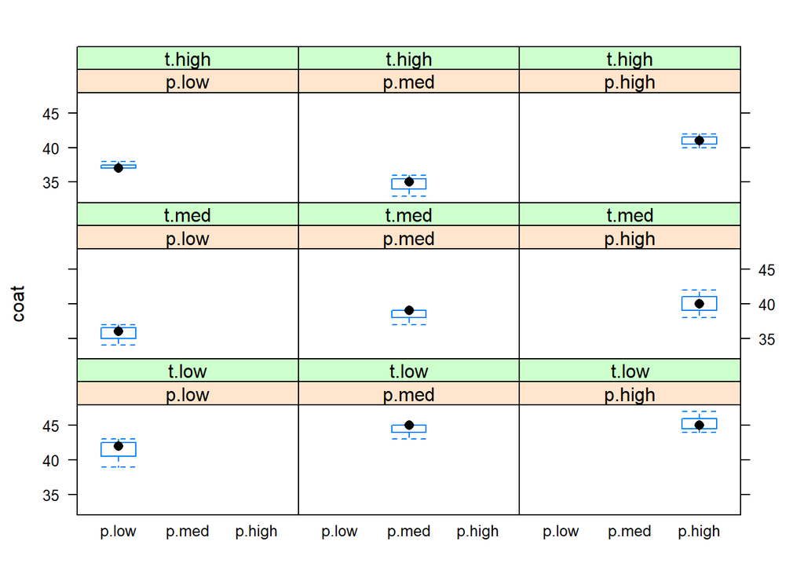

```r
bwplot(coat~pressure|pressure+temprt,data=filmcoat)
```

시각적 탐색을 위해 **filmcoat**에 대한 `bwplot`을 이용하여 **boxplot**을 그려주었다.

```r
library(reshape2)
acast(filmcoat,temprt~pressure,mean,value.var="coat",margins=TRUE)
```

```
##           p.low    p.med   p.high    (all)
## t.low  41.33333 44.33333 45.33333 43.66667
## t.med  35.66667 38.33333 40.00000 38.00000
## t.high 37.33333 34.66667 41.00000 37.66667
## (all)  38.11111 39.11111 42.11111 39.77778
```

`acast`함수를 이용하여 **filmcoat**데이터에 대한 평균을 한 눈에 보기 쉽게 정리할 수 있다.

```r
film.aov1 <- aov(coat ~ temprt*pressure,data=filmcoat)
summary(film.aov1)
```

```
##                 Df Sum Sq Mean Sq F value   Pr(>F)
## temprt           2 204.67  102.33  47.638 6.46e-08 ***
## pressure         2  78.00   39.00  18.155 4.83e-05 ***
## temprt:pressure  4  37.33    9.33   4.345   0.0124 *
## Residuals       18  38.67    2.15
## ---
## Signif. codes:  0 '***' 0.001 '**' 0.01 '*' 0.05 '.' 0.1 ' ' 1
```

**filmcoat**에 대한 분산분석을 진행한 결과, 주효과와 교호작용이 모두 유의한 결과를 나타내는 것을 확인할 수 있다.

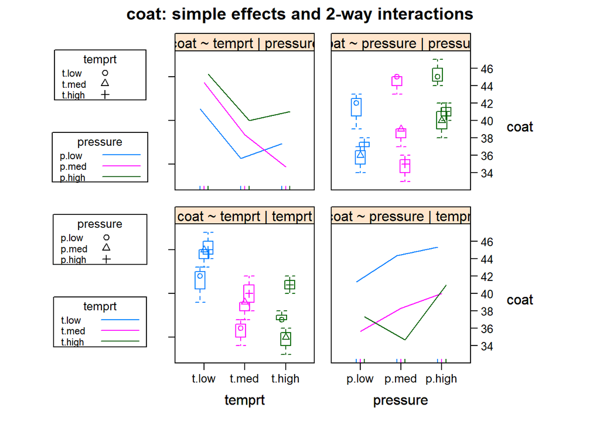

```r
interaction2wt(coat~temprt*pressure,data=filmcoat,simple=TRUE)
```

**filmcoat**의 교호작용 패널을 살펴보면 직선이 평행하지 않으며 교차점을 가지는 것으로 보아 교호작용이 어느정도 유의함을 알 수 있다.

```r
film.mmc1 <- mmc(film.aov1,focus="pressure")
film.mmc1
```

```
## Tukey contrasts
## Fit: aov(formula = coat ~ temprt * pressure, data = filmcoat)
## Estimated Quantile = 2.553088
## 95% family-wise confidence level
## $mca
##              estimate   stderr      lower    upper   height
## p.high-p.med        3 0.690917  1.2360281 4.763972 40.61111
## p.high-p.low        4 0.690917  2.2360281 5.763972 40.11111
## p.med-p.low         1 0.690917 -0.7639719 2.763972 38.61111
## $none
##        estimate    stderr    lower    upper   height
## p.high 42.11111 0.4885521 40.86379 43.35843 42.11111
## p.med  39.11111 0.4885521 37.86379 40.35843 39.11111
## p.low  38.11111 0.4885521 36.86379 39.35843 38.11111
```

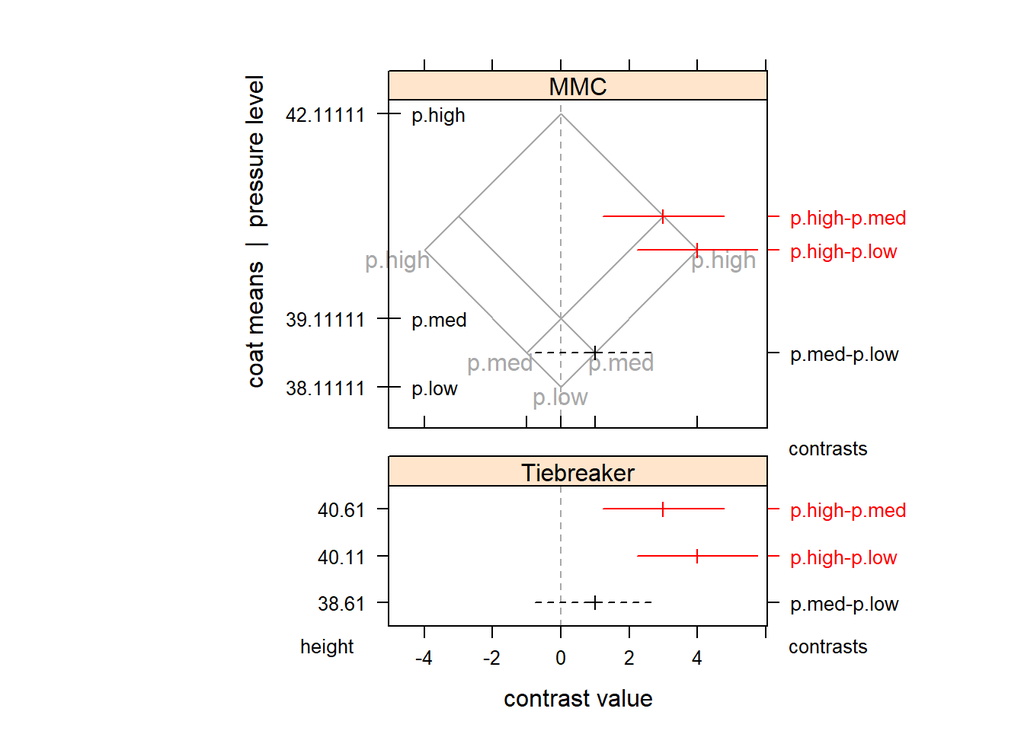

```r
mmcplot(film.mmc1,style="both")
```

`pressure`변수에 대한 다중비교를 진행한 결과, **p.high-p.med,p.high-p.low**의 집단 간 평균차이가 유의한 것을 알 수 있었다.

## 13.4 Nested Factorial Experiment

### 13.4.1 Example-Gunload Data

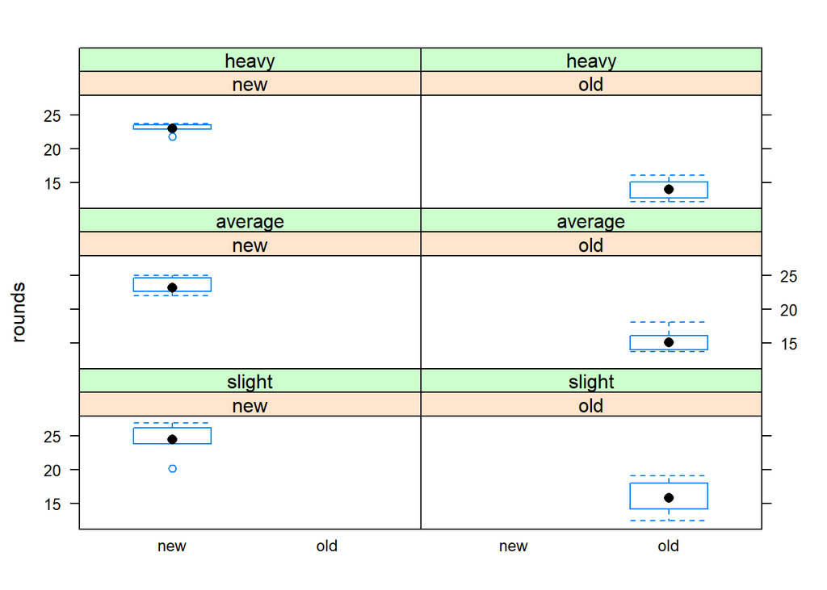

```r
data(gunload)
bwplot(rounds~method|method+group,data=gunload)
```

**gunload**데이터에 대해서 **method,group** 그룹 변수로 **rouns**를 종속변수로 지정하여 `boxplot`을 그렸다.

### 13.4.2 Example-Turkey Data (Continnued)

```r
gunload.aov <-
  aov(rounds ~ method*group + Error((team %in% group)/method),data=gunload)
summary(gunload.aov)
```

```
##
## Error: team:group
##           Df Sum Sq Mean Sq F value Pr(>F)
## group      2  16.05   8.026   1.227  0.358
## Residuals  6  39.26   6.543
##
## Error: team:group:method
##              Df Sum Sq Mean Sq F value   Pr(>F)
## method        1  652.0   652.0 364.841 1.33e-06 ***
## method:group  2    1.2     0.6   0.332     0.73
## Residuals     6   10.7     1.8
## ---
## Signif. codes:  0 '***' 0.001 '**' 0.01 '*' 0.05 '.' 0.1 ' ' 1
##
## Error: Within
##           Df Sum Sq Mean Sq F value Pr(>F)
## Residuals 18  41.59   2.311
```

```r
model.tables(gunload.aov,type="means")
```

```
## Tables of means
## Grand mean
##
## 19.33333
##
##  method
## method
##    new    old
## 23.589 15.078
##
##  group
## group
##  slight average   heavy
##  20.125  19.383  18.492
##
##  method:group
##       group
## method slight average heavy
##    new 24.350 23.433  22.983
##    old 15.900 15.333  14.000
```

또한, Error가 분수의 형태로 돼있으므로 metohd -> group -> team의 형태로 nested 된다는 것을 나타낸다.

```r
data(turkey)
turkey[c(1,7,13,19,25),]
```

```
##       diet wt.gain
## 1  control     4.1
## 7       A1     5.2
## 13      A2     6.3
## 19      B1     6.5
## 25      B2     9.5
```

```r
turkey$trt.vs.control <-
  factor(rep(c("control","treatment"),c(6,24)))
contrasts(turkey$trt.vs.control) <- c(4,-1)


turkey$additive <- factor(rep(c("control","A","B"),c(6,12,12)),
                          levels=c("control","A","B"))

contrasts(turkey$additive) <- c(0,1,-1)

turkey$amount <- factor((rep(c(0,1,2,1,2),c(6,6,6,6,6))))

contrasts(turkey$amount) <- c(0,1,-1)
turkey[c(1,7,13,19,25),]
```

```
##       diet wt.gain trt.vs.control additive amount
## 1  control     4.1        control  control      0
## 7       A1     5.2      treatment        A      1
## 13      A2     6.3      treatment        A      2
## 19      B1     6.5      treatment        B      1
## 25      B2     9.5      treatment        B      2
```

`trt.vs.control`변수는 **diet**변수가 **control**이면 control, 나머지에 대해서는 **treatment**를 반환한다.

`additive`의 경우 **control** = control, **A** = A, **B** = B를 반환한다.

`amount`변수는 **control** = 0, *diet* 변수의 마지막 숫자가 1이면 1, 2면 2를 반환한다.

```r
turkey3.aov <- aov(wt.gain ~ trt.vs.control / (additive*amount),data=turkey,x=TRUE)
summary(turkey3.aov)
```

```
##                                Df Sum Sq Mean Sq F value   Pr(>F)
## trt.vs.control                  1  56.58   56.58 179.395 6.58e-13 ***
## trt.vs.control:additive         1  22.81   22.81  72.337 7.56e-09 ***
## trt.vs.control:amount           1  22.43   22.43  71.105 8.88e-09 ***
## trt.vs.control:additive:amount  1   1.21    1.21   3.852   0.0609 .
## Residuals                      25   7.88    0.32
## ---
## Signif. codes:  0 '***' 0.001 '**' 0.01 '*' 0.05 '.' 0.1 ' ' 1
```

앞서 우리가 설정한 변수와 control, treatment에 대해서 분산분석을 진행하였다.  
control과 treatment 집단 간은 유의한 차이가 있음을 알 수 있고 **additive,amount** 또한 집단 간 유의한 차이가 있는 것을 확인할 수 있다. 교호작용의 유의확률은 0.0609로 유의수준 0.05보다 높으므로 유의하지 않다.  
하지만, 0.05에 매우 가까운 값을 가지므로 유의수준에 따라 유의하다고 해석할 수도 있다.

```r
print(na.print="",tapply(turkey$wt.gain,turkey[,c("additive","amount")],mean))
```

```
##          amount
## additive         0   1        2
##   control 3.783333
##   A                5.5 6.983333
##   B                7.0 9.383333
```

*treatment*에 따른 **amount,additive**에 대한 평균을 `tapply` 함수를 이용하여 구해주었다.

## 13.5 Specification of Model Formulas

```r
data(abc)
abc
```

```
##     A B  AB BwA     y
## r.w r w r.w   c -0.02
## r.x r x r.x   d  1.19
## r.y r y r.y   e -0.02
## r.z r z r.z   f  0.23
## s.w s w s.w   g  0.67
## s.x s x s.x   h  1.95
## s.y s y s.y   i -0.71
## s.z s z s.z   j -0.40
## t.w t w t.w   k -0.56
## t.x t x t.x   l  0.01
## t.y t y t.y   m  0.13
## t.z t z t.z   n  1.19
```

```r
abc.oneway <- with(abc,matrix(y,4,3,dimnames=list(1:4,A=unique(A))))

abc.oneway
```

```
##    A
##         r     s     t
##   1 -0.02  0.67 -0.56
##   2  1.19  1.95  0.01
##   3 -0.02 -0.71  0.13
##   4  0.23 -0.40  1.19
```

```r
abc.crossed <- with(abc,matrix(y,3,4,byrow=TRUE,
                               dimnames=list(A=unique(A),B=unique(B))))

abc.crossed
```

```
##    B
## A       w    x     y     z
##   r -0.02 1.19 -0.02  0.23
##   s  0.67 1.95 -0.71 -0.40
##   t -0.56 0.01  0.13  1.19
```

abc데이터에 대해서 **abc.oneway**데이터는 일원분산분석 형태의 matrix를 가지고 있다.  
**abc.crossed**는 이원분산분석 형태의 교차 matrix 형태를 가지고 있다.

```r
abc.nested <- with(abc,matrix(c(y[1:4],rep(NA,8),
                                rep(NA,4),y[5:8],
                                rep(NA,4),
                                rep(NA,8),y[9:12],3,12,byrow=TRUE,dimnames=list(A=unique(A),BwA=BwA))))

print(abc.nested,na.print="")
```

```
##       [,1]
##  [1,] -0.02
##  [2,] 1.19
##  [3,] -0.02
##  [4,] 0.23
##  [5,]
##  [6,]
##  [7,]
##  [8,]
##  [9,]
## [10,]
## [11,]
## [12,]
## [13,]
## [14,]
```

[output cut: 27 more lines]

```r
abc.double.indexed <- abc[,"y",drop=FALSE]
abc.double.indexed
```

```
##         y
## r.w -0.02
## r.x  1.19
## r.y -0.02
## r.z  0.23
## s.w  0.67
## s.x  1.95
## s.y -0.71
## s.z -0.40
## t.w -0.56
## t.x  0.01
## t.y  0.13
## t.z  1.19
```

```r
## one-way
abc.A.aov <- aov(y ~ A, data = abc)
anova(abc.A.aov)
```

```
## Analysis of Variance Table
##
## Response: y
##           Df Sum Sq Mean Sq F value Pr(>F)
## A          2 0.0781 0.03903  0.0506 0.9509
## Residuals  9 6.9377 0.77085
```

```r
coef(abc.A.aov)
```

```
## (Intercept)          As          At
##      0.3450      0.0325     -0.1525
```

```r
contrasts(abc$A)
```

```
##   s t
## r 0 0
## s 1 0
## t 0 1
```

```r
model.matrix(abc.A.aov)
```

```
##     (Intercept) As At
## r.w           1  0  0
## r.x           1  0  0
## r.y           1  0  0
## r.z           1  0  0
## s.w           1  1  0
## s.x           1  1  0
## s.y           1  1  0
## s.z           1  1  0
## t.w           1  0  1
## t.x           1  0  1
## t.y           1  0  1
## t.z           1  0  1
## attr(,"assign")
## [1] 0 1 1
## attr(,"contrasts")
## attr(,"contrasts")$A
## [1] "contr.treatment"
```

**abc.oneway**에 대해서 분산분석을 진행한 결과, 유의확률이 유의수준보다 크므로 유의한 차이가 발생하는 집단이 없는 것을 알 수 있다.

**contrasts**를 통해 dummy변수가 어떻게 처리 됐는지 알 수 있으며, model.matrix를 통해 contrast matrix의 조합을 살펴볼 수 있다.

```r
## crossed: no interaction
abc.ApB.aov <- aov(y ~ A+B, data = abc)
anova(abc.ApB.aov)
```

```
## Analysis of Variance Table
##
## Response: y
##           Df Sum Sq Mean Sq F value Pr(>F)
## A          2 0.0781 0.03903  0.0547 0.9472
## B          3 2.6607 0.88690  1.2442 0.3736
## Residuals  6 4.2770 0.71283
```

```r
coef(abc.ApB.aov)
```

```
## (Intercept)          As          At          Bx          By          Bz
##      0.0700      0.0325     -0.1525      1.0200     -0.2300      0.3100
```

```r
contrasts(abc$A)
```

```
##   s t
## r 0 0
## s 1 0
## t 0 1
```

```r
contrasts(abc$B)
```

```
##   x y z
## w 0 0 0
## x 1 0 0
## y 0 1 0
## z 0 0 1
```

```r
model.matrix(abc.ApB.aov)
```

```
##     (Intercept) As At Bx By Bz
## r.w           1  0  0  0  0  0
## r.x           1  0  0  1  0  0
## r.y           1  0  0  0  1  0
## r.z           1  0  0  0  0  1
## s.w           1  1  0  0  0  0
## s.x           1  1  0  1  0  0
## s.y           1  1  0  0  1  0
## s.z           1  1  0  0  0  1
## t.w           1  0  1  0  0  0
## t.x           1  0  1  1  0  0
## t.y           1  0  1  0  1  0
## t.z           1  0  1  0  0  1
## attr(,"assign")
## [1] 0 1 1 2 2 2
## attr(,"contrasts")
## attr(,"contrasts")$A
## [1] "contr.treatment"
##
## attr(,"contrasts")$B
## [1] "contr.treatment"
```

**abc.corossed**에 대해서 분산분석을 진행한 결과, 두 변수 모두 유의확률이 유의수준보다 크므로 유의한 차이가 발생하는 집단이 없는 것을 알 수 있다.

```r
## crossed: with interaction
abc.AsB.aov <- aov(y ~ A*B, data = abc)
anova(abc.AsB.aov)
```

```
## Analysis of Variance Table
##
## Response: y
##           Df Sum Sq Mean Sq F value Pr(>F)
## A          2 0.0781 0.03903
## B          3 2.6607 0.88690
## A:B        6 4.2770 0.71283
## Residuals  0 0.0000
```

```r
coef(abc.AsB.aov)
```

```
##   (Intercept)            As            At            Bx            By
## -2.000000e-02  6.900000e-01 -5.400000e-01  1.210000e+00  7.850462e-17
##            Bz         As:Bx         At:Bx         As:By         At:By
##  2.500000e-01  7.000000e-02 -6.400000e-01 -1.380000e+00  6.900000e-01
##         As:Bz         At:Bz
## -1.320000e+00  1.500000e+00
```

```r
contrasts(abc$A)
```

```
##   s t
## r 0 0
## s 1 0
## t 0 1
```

```r
contrasts(abc$B)
```

```
##   x y z
## w 0 0 0
## x 1 0 0
## y 0 1 0
## z 0 0 1
```

```r
contrasts(abc$AB)
```

```
##     r.x r.y r.z s.w s.x s.y s.z t.w t.x t.y t.z
## r.w   0   0   0   0   0   0   0   0   0   0   0
## r.x   1   0   0   0   0   0   0   0   0   0   0
## r.y   0   1   0   0   0   0   0   0   0   0   0
## r.z   0   0   1   0   0   0   0   0   0   0   0
## s.w   0   0   0   1   0   0   0   0   0   0   0
## s.x   0   0   0   0   1   0   0   0   0   0   0
## s.y   0   0   0   0   0   1   0   0   0   0   0
## s.z   0   0   0   0   0   0   1   0   0   0   0
## t.w   0   0   0   0   0   0   0   1   0   0   0
## t.x   0   0   0   0   0   0   0   0   1   0   0
## t.y   0   0   0   0   0   0   0   0   0   1   0
## t.z   0   0   0   0   0   0   0   0   0   0   1
```

```r
model.matrix(abc.AsB.aov)
```

```
##     (Intercept) As At Bx By Bz As:Bx At:Bx As:By At:By As:Bz At:Bz
## r.w           1  0  0  0  0  0     0     0     0     0     0     0
## r.x           1  0  0  1  0  0     0     0     0     0     0     0
## r.y           1  0  0  0  1  0     0     0     0     0     0     0
## r.z           1  0  0  0  0  1     0     0     0     0     0     0
## s.w           1  1  0  0  0  0     0     0     0     0     0     0
## s.x           1  1  0  1  0  0     1     0     0     0     0     0
## s.y           1  1  0  0  1  0     0     0     1     0     0     0
## s.z           1  1  0  0  0  1     0     0     0     0     1     0
## t.w           1  0  1  0  0  0     0     0     0     0     0     0
## t.x           1  0  1  1  0  0     0     1     0     0     0     0
## t.y           1  0  1  0  1  0     0     0     0     1     0     0
## t.z           1  0  1  0  0  1     0     0     0     0     0     1
## attr(,"assign")
##  [1] 0 1 1 2 2 2 3 3 3 3 3 3
## attr(,"contrasts")
## attr(,"contrasts")$A
## [1] "contr.treatment"
##
## attr(,"contrasts")$B
## [1] "contr.treatment"
```

crossed의 경우 뒤에 Formula에 *+*가 아닌 `*`를 사용함으로써 교호작용을 함께 살펴볼 수 있다.

```r
## nested
abc.BwA.aov <- aov(y ~ A/B, data = abc)
anova(abc.BwA.aov)
```

```
## Analysis of Variance Table
##
## Response: y
##           Df Sum Sq Mean Sq F value Pr(>F)
## A          2 0.0781 0.03903
## A:B        9 6.9377 0.77085
## Residuals  0 0.0000
```

```r
coef(abc.BwA.aov)
```

```
##   (Intercept)            As            At         Ar:Bx         As:Bx
## -2.000000e-02  6.900000e-01 -5.400000e-01  1.210000e+00  1.280000e+00
##         At:Bx         Ar:By         As:By         At:By         Ar:Bz
##  5.700000e-01  2.362077e-16 -1.380000e+00  6.900000e-01  2.500000e-01
##         As:Bz         At:Bz
## -1.070000e+00  1.750000e+00
```

```r
contrasts(abc$A)
```

```
##   s t
## r 0 0
## s 1 0
## t 0 1
```

```r
contrasts(interaction(abc$A,abc$B))
```

```
##     s.w t.w r.x s.x t.x r.y s.y t.y r.z s.z t.z
## r.w   0   0   0   0   0   0   0   0   0   0   0
## s.w   1   0   0   0   0   0   0   0   0   0   0
## t.w   0   1   0   0   0   0   0   0   0   0   0
## r.x   0   0   1   0   0   0   0   0   0   0   0
## s.x   0   0   0   1   0   0   0   0   0   0   0
## t.x   0   0   0   0   1   0   0   0   0   0   0
## r.y   0   0   0   0   0   1   0   0   0   0   0
## s.y   0   0   0   0   0   0   1   0   0   0   0
## t.y   0   0   0   0   0   0   0   1   0   0   0
## r.z   0   0   0   0   0   0   0   0   1   0   0
## s.z   0   0   0   0   0   0   0   0   0   1   0
## t.z   0   0   0   0   0   0   0   0   0   0   1
```

```r
model.matrix(abc.BwA.aov)
```

```
##     (Intercept) As At Ar:Bx As:Bx At:Bx Ar:By As:By At:By Ar:Bz As:Bz At:Bz
## r.w           1  0  0     0     0     0     0     0     0     0     0     0
## r.x           1  0  0     1     0     0     0     0     0     0     0     0
## r.y           1  0  0     0     0     0     1     0     0     0     0     0
## r.z           1  0  0     0     0     0     0     0     0     1     0     0
## s.w           1  1  0     0     0     0     0     0     0     0     0     0
## s.x           1  1  0     0     1     0     0     0     0     0     0     0
## s.y           1  1  0     0     0     0     0     1     0     0     0     0
## s.z           1  1  0     0     0     0     0     0     0     0     1     0
## t.w           1  0  1     0     0     0     0     0     0     0     0     0
## t.x           1  0  1     0     0     1     0     0     0     0     0     0
## t.y           1  0  1     0     0     0     0     0     1     0     0     0
## t.z           1  0  1     0     0     0     0     0     0     0     0     1
## attr(,"assign")
##  [1] 0 1 1 2 2 2 2 2 2 2 2 2
## attr(,"contrasts")
## attr(,"contrasts")$A
## [1] "contr.treatment"
##
## attr(,"contrasts")$B
## [1] "contr.treatment"
```

**nested**의 경우, **/**형태의 Formula를 사용함으로써 nested된 분산분석의 결과를 살펴볼볼 수 있다.

```r
## doublyindexed
abc.AB.aov <- aov(y ~ AB, data = abc)
anova(abc.AB.aov)
```

```
## Analysis of Variance Table
##
## Response: y
##           Df Sum Sq Mean Sq F value Pr(>F)
## AB        11 7.0157 0.63779
## Residuals  0 0.0000
```

```r
coef(abc.AB.aov)
```

```
##   (Intercept)         ABr.x         ABr.y         ABr.z         ABs.w
## -2.000000e-02  1.210000e+00  3.638787e-18  2.500000e-01  6.900000e-01
##         ABs.x         ABs.y         ABs.z         ABt.w         ABt.x
##  1.970000e+00 -6.900000e-01 -3.800000e-01 -5.400000e-01  3.000000e-02
##         ABt.y         ABt.z
##  1.500000e-01  1.210000e+00
```

```r
contrasts(abc$B)
```

```
##   x y z
## w 0 0 0
## x 1 0 0
## y 0 1 0
## z 0 0 1
```

```r
model.matrix(abc.AB.aov)
```

```
##     (Intercept) ABr.x ABr.y ABr.z ABs.w ABs.x ABs.y ABs.z ABt.w ABt.x ABt.y
## r.w           1     0     0     0     0     0     0     0     0     0     0
## r.x           1     1     0     0     0     0     0     0     0     0     0
## r.y           1     0     1     0     0     0     0     0     0     0     0
## r.z           1     0     0     1     0     0     0     0     0     0     0
## s.w           1     0     0     0     1     0     0     0     0     0     0
## s.x           1     0     0     0     0     1     0     0     0     0     0
## s.y           1     0     0     0     0     0     1     0     0     0     0
## s.z           1     0     0     0     0     0     0     1     0     0     0
## t.w           1     0     0     0     0     0     0     0     1     0     0
## t.x           1     0     0     0     0     0     0     0     0     1     0
## t.y           1     0     0     0     0     0     0     0     0     0     1
## t.z           1     0     0     0     0     0     0     0     0     0     0
##     ABt.z
## r.w     0
## r.x     0
## r.y     0
## r.z     0
## s.w     0
## s.x     0
## s.y     0
## s.z     0
## t.w     0
## t.x     0
## t.y     0
## t.z     1
## attr(,"assign")
##  [1] 0 1 1 1 1 1 1 1 1 1 1 1
## attr(,"contrasts")
## attr(,"contrasts")$AB
## [1] "contr.treatment"
```

```r
model.matrix(~A,data=abc,
             contrasts=list(A=contr.treatment))
```

```
##     (Intercept) A2 A3
## r.w           1  0  0
## r.x           1  0  0
## r.y           1  0  0
## r.z           1  0  0
## s.w           1  1  0
## s.x           1  1  0
## s.y           1  1  0
## s.z           1  1  0
## t.w           1  0  1
## t.x           1  0  1
## t.y           1  0  1
## t.z           1  0  1
## attr(,"assign")
## [1] 0 1 1
## attr(,"contrasts")
## attr(,"contrasts")$A
##   2 3
## r 0 0
## s 1 0
## t 0 1
```

`model.matrix`의 option인 `contr.treatment`를 사용한 결과, **ABC**데이터의 A변수에 대한 contrast matrix를 살펴볼 수 있다.

```r
model.matrix(~A,data=abc,contrasts=list(A=contr.sum))
```

```
##     (Intercept) A1 A2
## r.w           1  1  0
## r.x           1  1  0
## r.y           1  1  0
## r.z           1  1  0
## s.w           1  0  1
## s.x           1  0  1
## s.y           1  0  1
## s.z           1  0  1
## t.w           1 -1 -1
## t.x           1 -1 -1
## t.y           1 -1 -1
## t.z           1 -1 -1
## attr(,"assign")
## [1] 0 1 1
## attr(,"contrasts")
## attr(,"contrasts")$A
##   [,1] [,2]
## r    1    0
## s    0    1
## t   -1   -1
```

`contr.sum`을 지정해준 결과, 절편을 제외한 matrix의 열에 대하여 누적 합이 0이 되도록 조합을 만들어준다.

### 13.5.1 Crossing of Two Factor

```r
old.width <- options(width=70)

mm <- model.matrix(~A*B,data=abc,
                   contrasts=list(A=contr.helmert,
                                  B=contr.helmert))
mm[,]
```

```
##     (Intercept) A1 A2 B1 B2 B3 A1:B1 A2:B1 A1:B2 A2:B2 A1:B3 A2:B3
## r.w           1 -1 -1 -1 -1 -1     1     1     1     1     1     1
## r.x           1 -1 -1  1 -1 -1    -1    -1     1     1     1     1
## r.y           1 -1 -1  0  2 -1     0     0    -2    -2     1     1
## r.z           1 -1 -1  0  0  3     0     0     0     0    -3    -3
## s.w           1  1 -1 -1 -1 -1    -1     1    -1     1    -1     1
## s.x           1  1 -1  1 -1 -1     1    -1    -1     1    -1     1
## s.y           1  1 -1  0  2 -1     0     0     2    -2    -1     1
## s.z           1  1 -1  0  0  3     0     0     0     0     3    -3
## t.w           1  0  2 -1 -1 -1     0    -2     0    -2     0    -2
## t.x           1  0  2  1 -1 -1     0     2     0    -2     0    -2
## t.y           1  0  2  0  2 -1     0     0     0     4     0    -2
## t.z           1  0  2  0  0  3     0     0     0     0     0     6
```

```r
print(AA <- mm["s.y",c("A1","A2")])
```

```
## A1 A2
##  1 -1
```

```r
print(BBB <- mm["s.y",c("B1","B2","B3")])
```

```
## B1 B2 B3
##  0  2 -1
```

```r
outer(AA,BBB)
```

```
##    B1 B2 B3
## A1  0  2 -1
## A2  0 -2  1
```

```r
as.vector(outer(AA,BBB))
```

```
## [1]  0  0  2 -2 -1  1
```

```r
mm["s.y",c("A1:B1","A2:B1","A1:B2","A2:B2","A1:B3","A2:B3")]
```

```
## A1:B1 A2:B1 A1:B2 A2:B2 A1:B3 A2:B3
##     0     0     2    -2    -1     1
```

```r
options(old.width)
```

## 13.6 Sequential and Conditional Tests

자료에 2개 이상의 종속변수가 존재하는 경우, 아래와 같은 분석방법을 통해서 실험을 진행할 수 있다.

```r
match(dimnames(coef(summary.lm(turkey3.aov)))[[1]],dimnames(turkey3.aov$x)[[2]])
```

```
## [1]  1  2  4  8 12
```

```r
turkey[c(1,7,13,19,25),]
```

```
##       diet wt.gain trt.vs.control additive amount
## 1  control     4.1        control  control      0
## 7       A1     5.2      treatment        A      1
## 13      A2     6.3      treatment        A      2
## 19      B1     6.5      treatment        B      1
## 25      B2     9.5      treatment        B      2
```

```r
turkey3.coef <- summary.lm(turkey3.aov)$coef

turkey3.x <- turkey3.aov$x

term.names <- c("(Intercept)","trt.vs.control","additive","amount","additive:amount")

dimnames(turkey3.coef)[[1]] <- term.names
dimnames(turkey3.x)[[2]][c(1,2,4,8,12)] <- term.names

zapsmall(turkey3.coef)
```

```
##                 Estimate Std. Error   t value Pr(>|t|)
## (Intercept)      6.53000    0.10253  63.68585   0.0000
## trt.vs.control  -0.68667    0.05127 -13.39386   0.0000
## additive        -0.97500    0.11464  -8.50510   0.0000
## amount          -0.96667    0.11464  -8.43241   0.0000
## additive:amount  0.22500    0.11464   1.96272   0.0609
```

```r
turkey3.x[c(1,7,13,19,25),c(1,2,4,8,12)]
```

```
##    (Intercept) trt.vs.control additive amount additive:amount
## 1            1              4        0      0               0
## 7            1             -1        1      1               1
## 13           1             -1        1     -1              -1
## 19           1             -1       -1      1              -1
## 25           1             -1       -1     -1               1
```

### 13.6.2 Example-Application to Clover Data

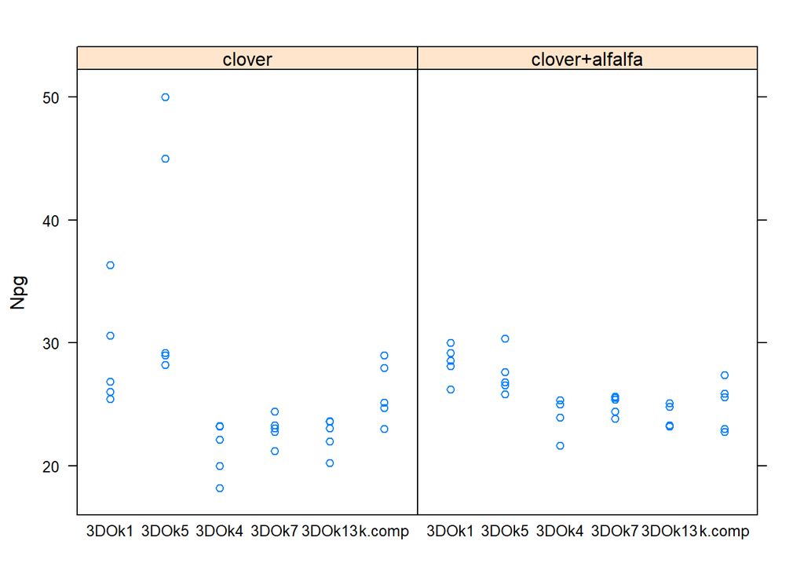

```r
data("rhiz.clover")

stripplot(Npg~strain|comb,data=rhiz.clover)
```

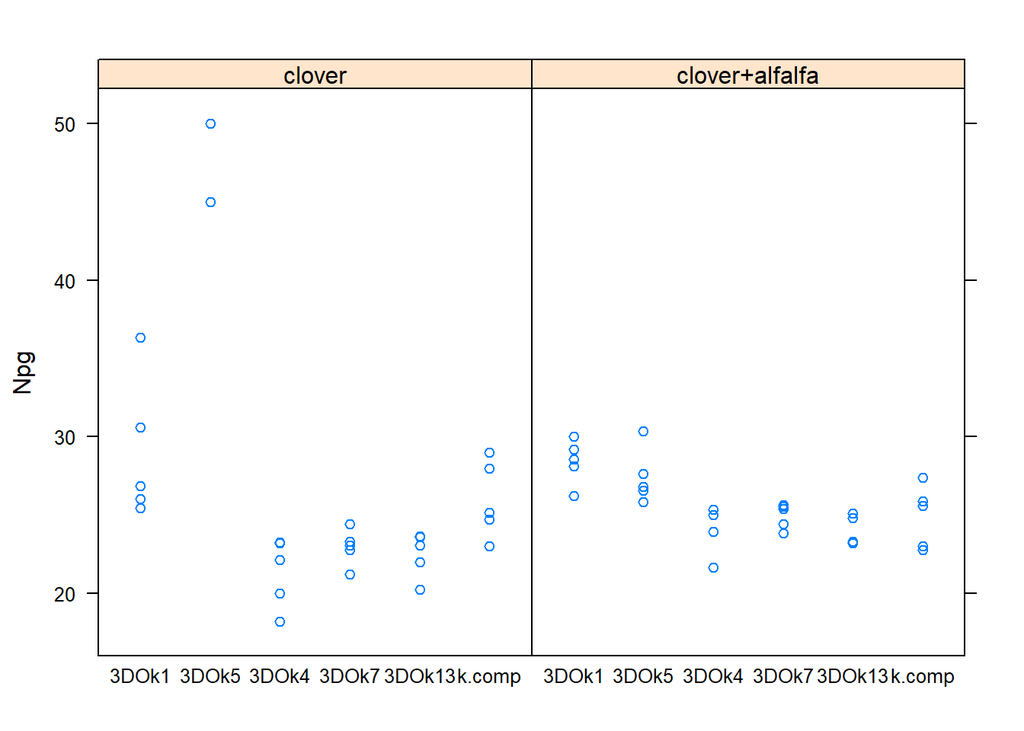

```r
rhiz.clover2 <- rhiz.clover[-c(7,9,10),]
stripplot(Npg~strain|comb,data=rhiz.clover2)
```

**rhiz.clover**대해서 **comb**를 그룹변수로 하고 **strain**과 **Npg**의 관계를 살펴보기 위해 `stripplot`함수를 사용하였다.

```r
library(car)
## drop two obervation to illustrate Type 2 Eand 3 sums of squares
## I am dropping the non-outlier observations in 300k5
cloverD <- rhiz.clover[-c(7,9,10),]

old.opt <- options(show.signif.stars = FALSE, digit=3)

cloverDsc.aov <- aov(Npg ~ strain*comb,data=cloverD,contrasts = list(strain=contr.sum,comb=contr.sum))

anova(cloverDsc.aov)[,c(2,1,4,5)]
```

```
##             Sum Sq Df F value    Pr(>F)
## strain      657.40  5 29.2810 4.237e-13
## comb         20.03  1  4.4614   0.04025
## strain:comb 594.34  5 26.4725 2.272e-12
## Residuals   202.06 45
```

`Anova`함수에서 `type = 2` 옵션을 지정하게 되면 불균형한 데이터셋에 대해서 Method of Fitting Constants의 test 결과를 확인할 수 있다.

```r
Anova(cloverDsc.aov,type=2)
```

```
## Anova Table (Type II tests)
##
## Response: Npg
##             Sum Sq Df F value    Pr(>F)
## strain      675.12  5 30.0702 2.700e-13
## comb         20.03  1  4.4614   0.04025
## strain:comb 594.34  5 26.4725 2.272e-12
## Residuals   202.06 45
```

`type = 3` 옵션을 지정할 경우, Weighted Sqaures of Means의 test 결과를 확인할 수 있다.

```r
Anova(cloverDsc.aov,type=3)
```

```
## Anova Table (Type III tests)
##
## Response: Npg
##             Sum Sq Df  F value    Pr(>F)
## (Intercept)  38711  1 8621.083 < 2.2e-16
## strain        1049  5   46.738 < 2.2e-16
## comb            86  1   19.256 6.830e-05
## strain:comb    594  5   26.473 2.272e-12
## Residuals      202 45
```

```r
cloverDsc.aov <- aov(Npg ~ comb*strain,data=cloverD,contrasts = list(strain=contr.sum,comb=contr.sum))

anova(cloverDsc.aov)[,c(2,1,4,5)]
```

```
##             Sum Sq Df F value    Pr(>F)
## comb          2.32  1  0.5157    0.4764
## strain      675.12  5 30.0702 2.700e-13
## comb:strain 594.34  5 26.4725 2.272e-12
## Residuals   202.06 45
```

```r
Anova(cloverDsc.aov,type=2)
```

```
## Anova Table (Type II tests)
##
## Response: Npg
##             Sum Sq Df F value    Pr(>F)
## comb         20.03  1  4.4614   0.04025
## strain      675.12  5 30.0702 2.700e-13
## comb:strain 594.34  5 26.4725 2.272e-12
## Residuals   202.06 45
```

```r
Anova(cloverDsc.aov,type=3)
```

```
## Anova Table (Type III tests)
##
## Response: Npg
##             Sum Sq Df  F value    Pr(>F)
## (Intercept)  38711  1 8621.083 < 2.2e-16
## comb            86  1   19.256 6.830e-05
## strain        1049  5   46.738 < 2.2e-16
## comb:strain    594  5   26.473 2.272e-12
## Residuals      202 45
```

```r
options(old.opt)
```